# Session 3

### 3.4 Add the functional ecology theme we defined earlier to the plot

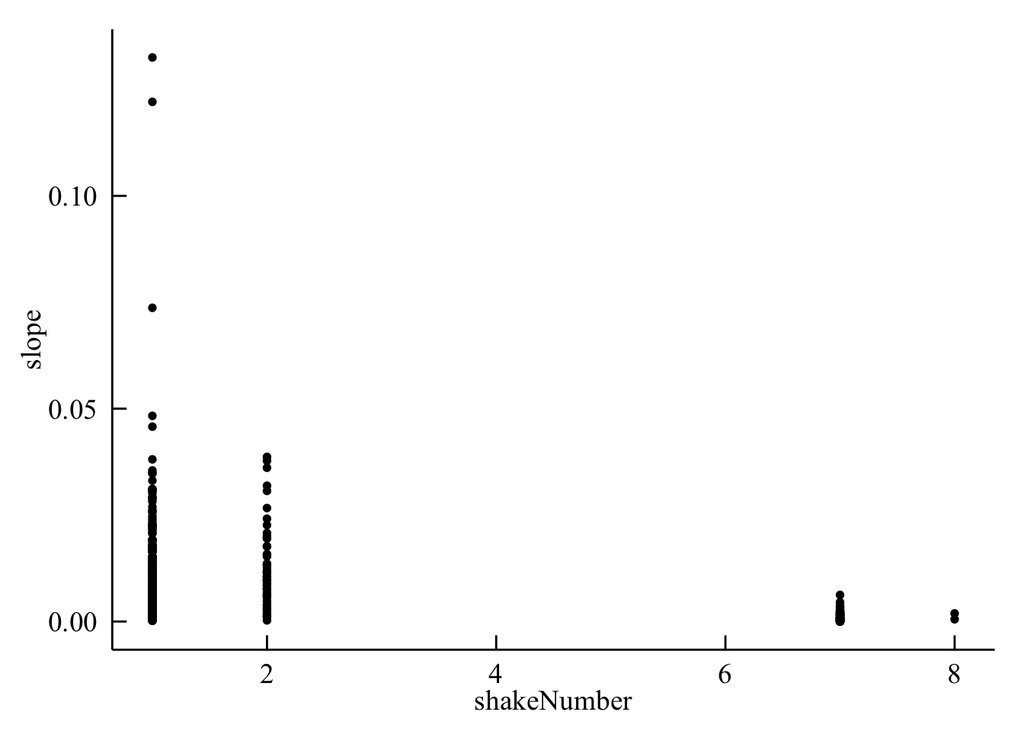

```r
ggplot(flr, aes(x = shakeNumber, y = slope)) +
     geom_point() +
     functEcolTheme
```

### 3.5 Add this to your previous graph, and see what happens:

```
 + geom_smooth()
```

```
## geom_smooth: method="auto" and size of largest group is <1000, so using loess. Use 'method = x' to change the smoothing method.
```

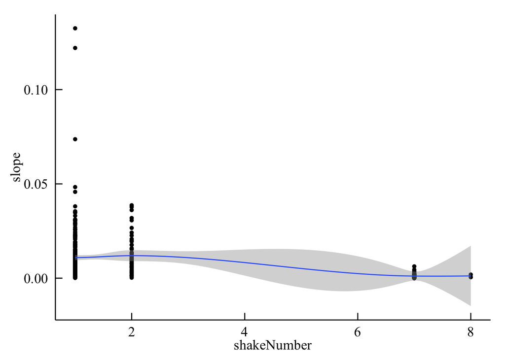

```r
ggplot(flr, aes(x = shakeNumber, y = slope)) +
     geom_point() +
     functEcolTheme +
     geom_smooth()
```

## Making boxplots

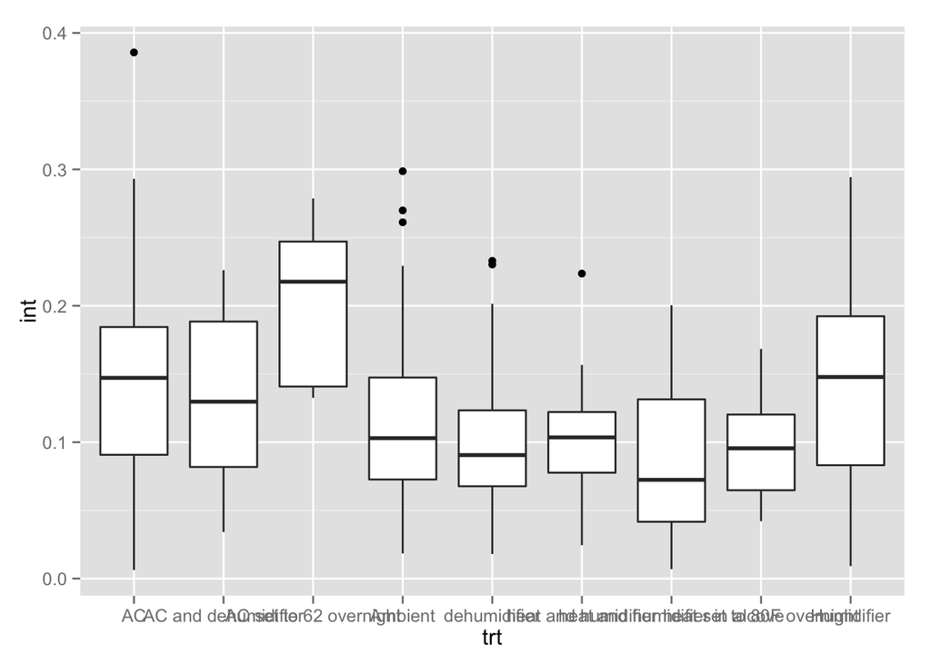

```r
plt3 <- ggplot(flr1, aes(x = trt, y = int)) +
     geom_boxplot()
plt3
```

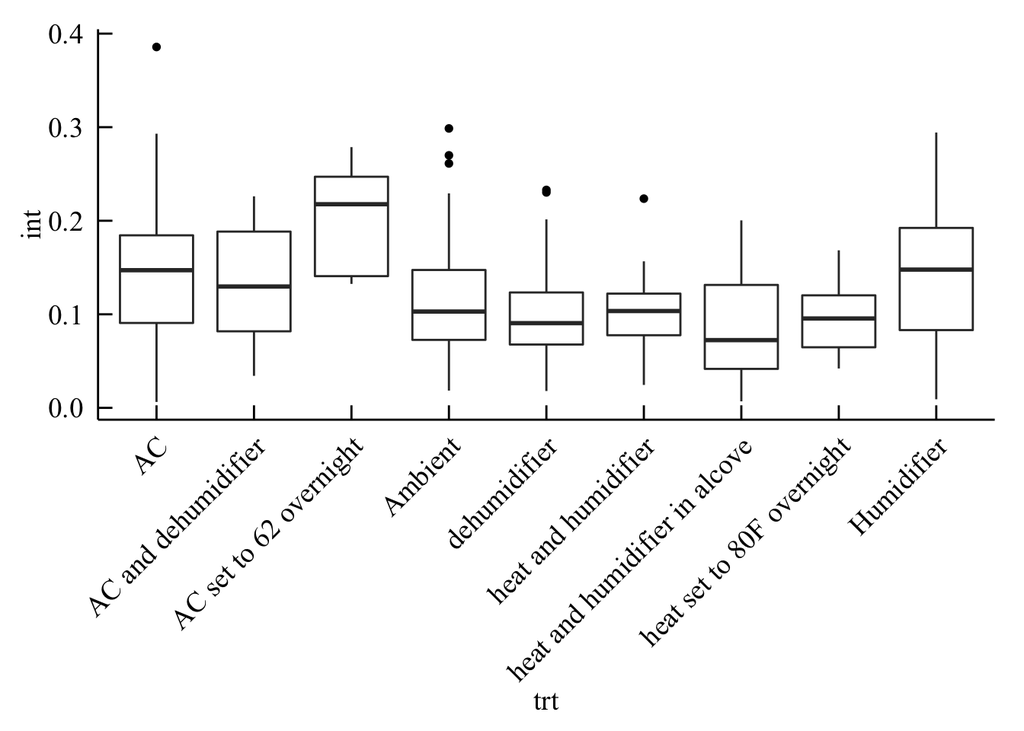

```r
plt3 + functEcolTheme +
     theme(axis.text.x = element_text(angle = 45, hjust = 1))
```

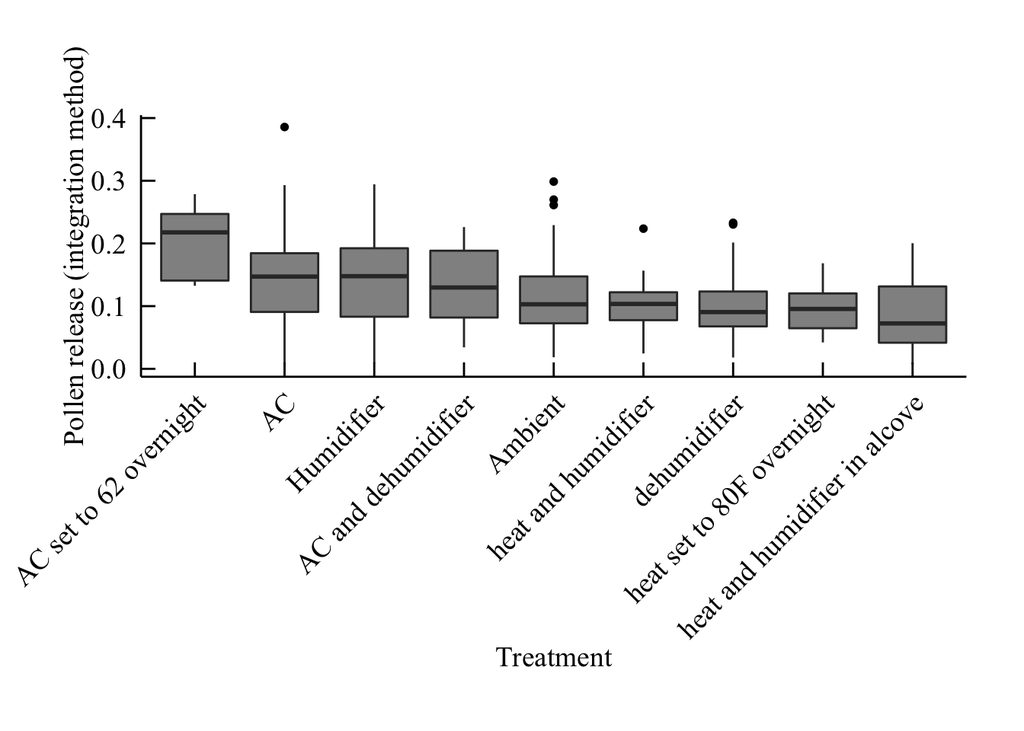

```r
# changing order of the boxes -- change levels of a factor
trtMeans <- tapply(X = flr1$int, FUN = mean, INDEX = flr1$trt)
trtMeans.sort <- trtMeans[order(trtMeans, decreasing = TRUE)]

flr1$trt <- factor(flr1$trt, levels = names(trtMeans.sort))

plt3.ordered <- ggplot(flr1, aes(x = trt, y = int)) +
     geom_boxplot(fill = 'black', alpha = 0.5) +
     functEcolTheme +
     theme(axis.text.x = element_text(angle = 45, hjust = 1),
           plot.margin = unit(c(2,1,1,1), "cm")) +
     labs(x = "Treatment", y = "Pollen release (integration method)")

plt3.ordered
```

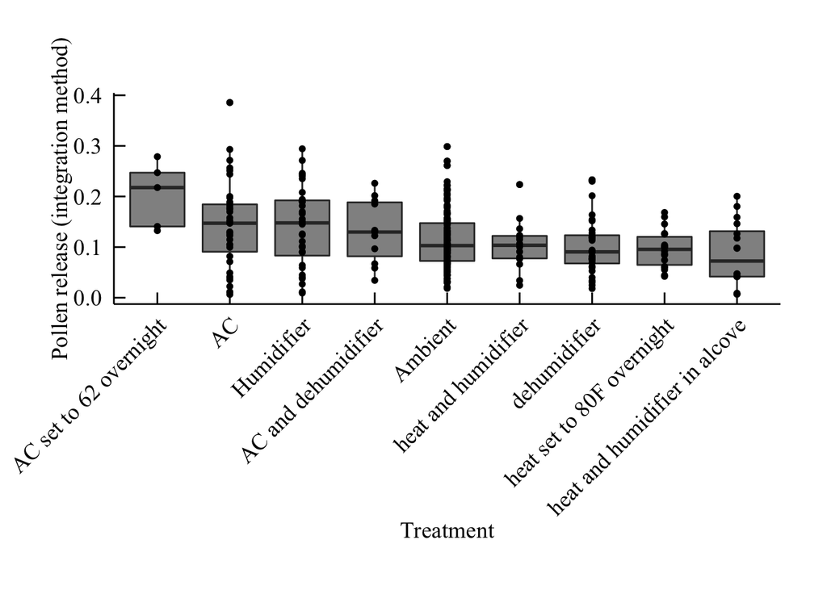

```r
plt3.ordered + geom_point()
```

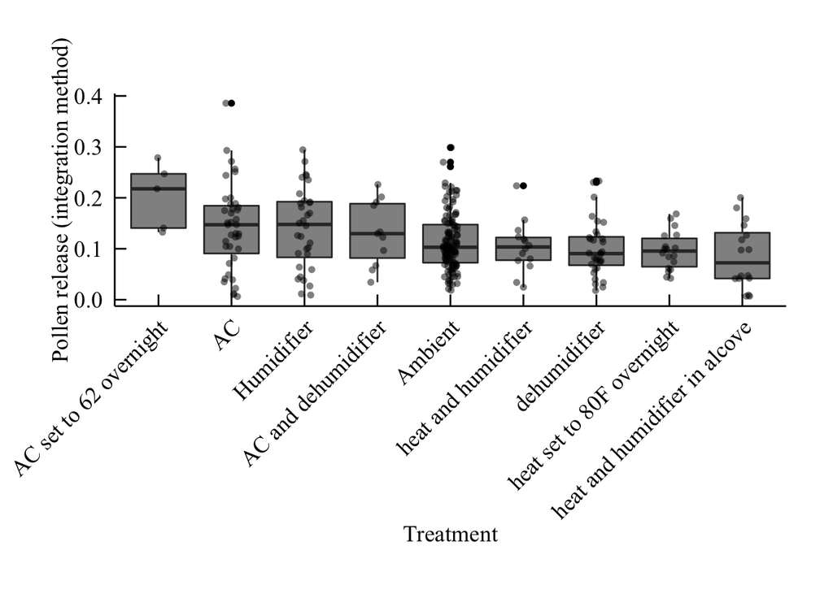

```r
plt4 <- plt3.ordered + geom_point(position = position_jitter(width = 0.1, height = 0), alpha = 0.5)
plt4
```

```r
ggsave("boxpltTrt.pdf", device = cairo_pdf, plot = plt4, width = 8, height = 6)
file.remove("boxpltTrt.pdf")
```

```
## [1] TRUE
```

Exercises(3, cont’):

### 3.6 Read in the “loblolly.txt” dataset, if you haven’t already. Call it “lob”. Use ggplot() to plot a scatterplot (geom_point()) with x= age, y = height.

```r
lob <- read.table("datasets/loblolly.txt", sep = " ", header = TRUE)
head(lob)
```

```
##   height age Seed
## 1   4.51   3  301
## 2  10.89   5  301
## 3  28.72  10  301
## 4  41.74  15  301
## 5  52.70  20  301
## 6  60.92  25  301
```

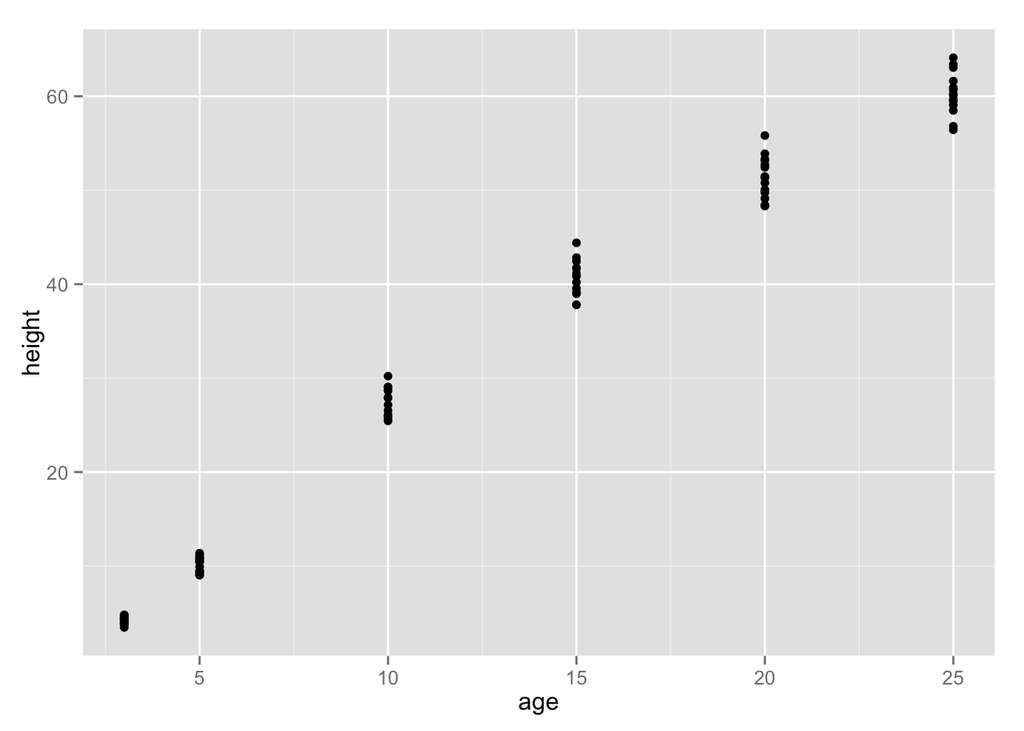

```r
ggplot(lob, aes(x = age, y = height)) +
     geom_point()
```

### 3.7 Using the “lob” dataframe, convert “age” to a factor.

```
 lob$age <- as.factor(lob$age)
```

### Now make a boxplot where x = age, and y = height with ggplot()

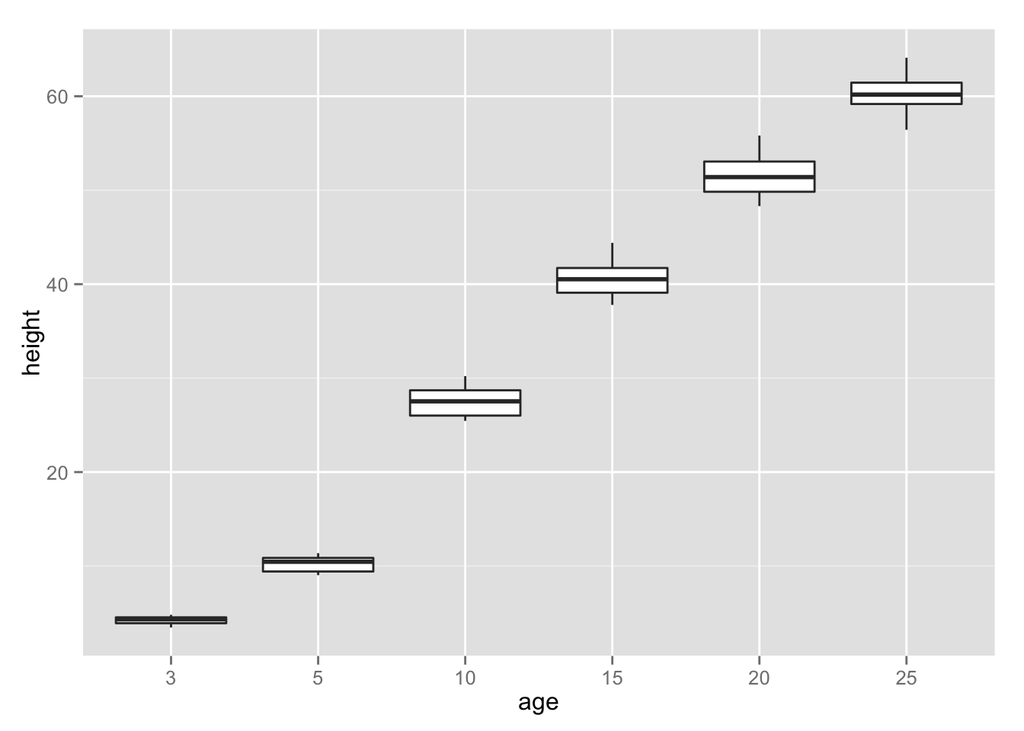

```r
lob$age <- as.factor(lob$age)

ggplot(lob, aes(x = age, y = height)) +
     geom_boxplot()
```

### 3.8 Using the “lob” dataframe, add points to the boxplot from 3.7. *Advanced change the color of the points, based on the “Seed” variable from the “lob” dataframe (you may want to convert it to a factor first)*

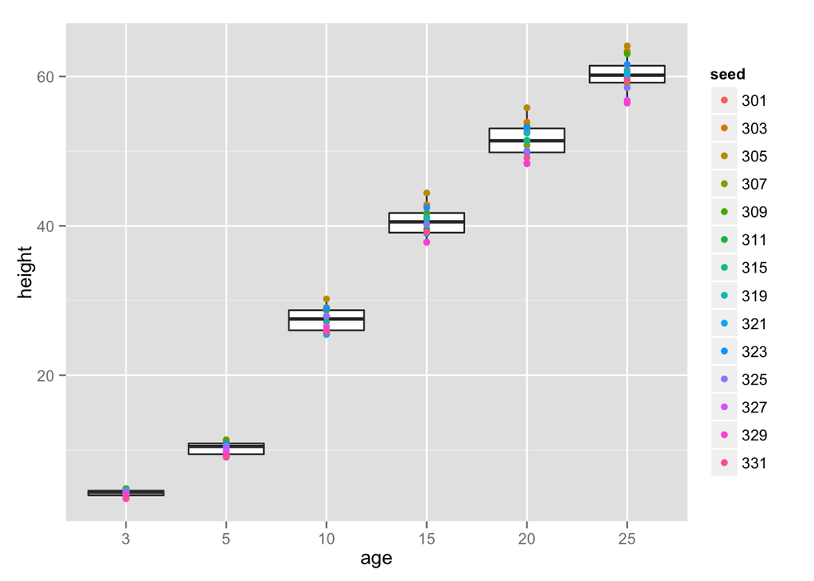

```r
seed <- as.factor(lob$Seed)

ggplot(lob, aes(x = age, y = height)) +
     geom_boxplot() +
     geom_point(aes(color = seed))
```